# ICY0006 - Probability Theory and Statistics - Matryg project, TalTech

Now I will train a regression model with multiple variables as both height in meter and age as the x-variables. I will refer to this model as model 2.

```r
fit_model2 <- lm(LungCap~Age+HeightMeter, data = train)
summary(fit_model2)
```

```
Call:
lm(formula = LungCap ~ Age + HeightMeter, data = train)

Residuals:
    Min      1Q  Median      3Q     Max
-3.4047 -0.6953  0.0086  0.7365  3.2158

Coefficients:
             Estimate Std. Error t value Pr(>|t|)
(Intercept) -11.59625    0.54762 -21.176  < 2e-16 ***
Age           0.11919    0.02076   5.742 1.51e-08 ***
HeightMeter  10.92532    0.45194  24.174  < 2e-16 ***
---
Signif. codes:  0 ‘***’ 0.001 ‘**’ 0.01 ‘*’ 0.05 ‘.’ 0.1 ‘ ’ 1

Residual standard error: 1.069 on 577 degrees of freedom
Multiple R-squared:  0.8373,    Adjusted R-squared:  0.8368
F-statistic:  1485 on 2 and 577 DF,  p-value: < 2.2e-16
```

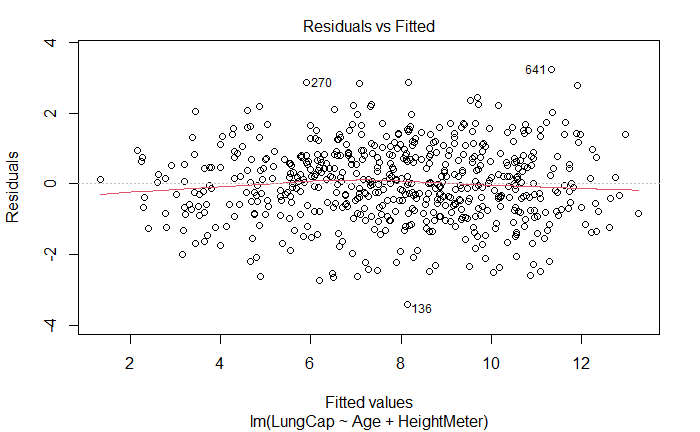

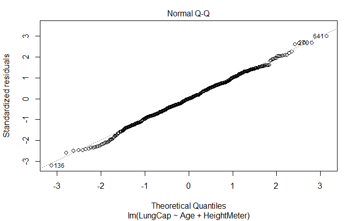

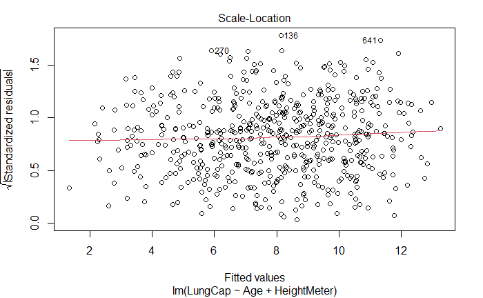

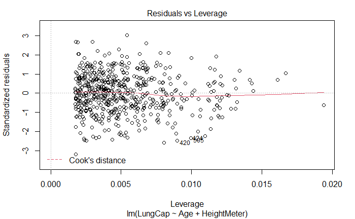

```r
plot(fit_model2)
```

From model 2 the main point for now is to look at the residual standard error, which is 1.069 and the R-squared is 0.8373 which is approx. 84 %. As can be seen on the residuals vs. fitted scatterplot the residuals are randomly distributed. The residual standard error and the R-squared will be discussed in a moment after having trained the last linear model with multiple variables which will be age, height in meter, smoke, gender and caesarean. I will refer to this model as model 3.

```r
fit_model3 <- lm(LungCap~Age+HeightMeter+Smoke+Gender+Caesarean, data = train)
summary(fit_model3)
```

```
Call:
lm(formula = LungCap ~ Age + HeightMeter + Smoke + Gender + Caesarean,
    data = train)

Residuals:
    Min      1Q  Median      3Q     Max
-3.3387 -0.7135  0.0804  0.6984  2.9957

Coefficients:
              Estimate Std. Error t value Pr(>|t|)
(Intercept)  -11.12298    0.53836 -20.661  < 2e-16 ***
Age            0.15967    0.02087   7.651 8.47e-14 ***
HeightMeter   10.28495    0.45625  22.543  < 2e-16 ***
Smokeyes      -0.65619    0.14085  -4.659 3.96e-06 ***
Gendermale     0.42259    0.08985   4.703 3.21e-06 ***
Caesareanyes  -0.26673    0.10214  -2.611  0.00926 **
---
Signif. codes:  0 ‘***’ 0.001 ‘**’ 0.01 ‘*’ 0.05 ‘.’ 0.1 ‘ ’ 1

Residual standard error: 1.024 on 574 degrees of freedom
Multiple R-squared:  0.8515,    Adjusted R-squared:  0.8502
F-statistic: 658.4 on 5 and 574 DF,  p-value: < 2.2e-16
```

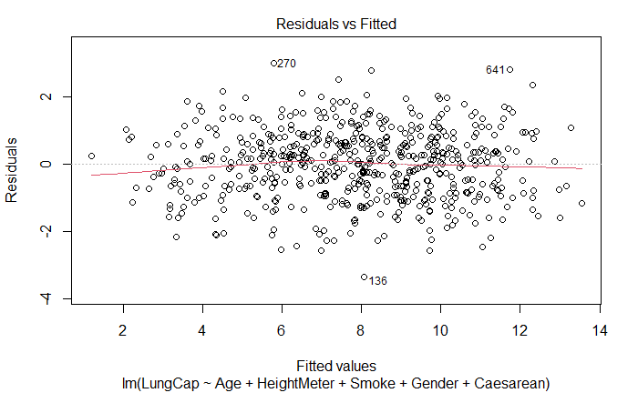

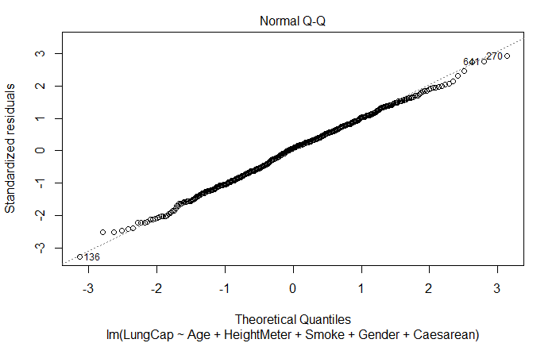

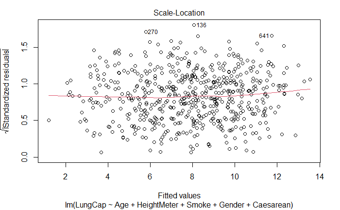

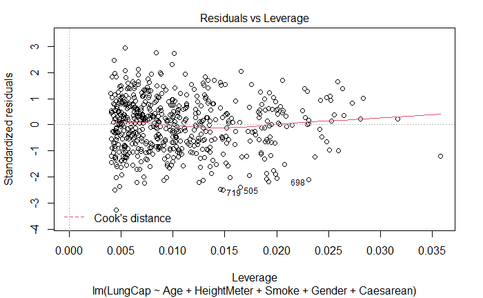

```r
plot(fit_model3)
```

```r
#train_model2 <- lm(training_set$LungCap ~ training_set$Age + training_set$HeightMeter + training_set$Smoke + training_set$Gender + training_set$Caesarean)
#summary(train_model2)
#plot(train_model2)
```

For model 3 the residual standard error is 1.024 and the R-squared is 0.8515 which is approx. 85 %. Compared with the other two models based on the training set, model 3 has the lowest error and highest percentage of R-squared which means that it explains 85 % of the dependent variable variation. Then follows model 2 and at last comes model 1.

## Testing the model

In the following I will test my models and evaluate how well they perform. To assess my models performance on unseen data I have trained them on the training data set and then I use the testing data set to compare predicted values with actual values. If the model is not tested and is made such that it performs good only on the training data set, then the parameters will be tuned in a way that they are only good enough to predict the value for the data which was in the training data set, and that is not generically applicable to any other data sets that I want to carry the model over to and that is called overfitting. I want to avoid overfitting and underfitting my models.

### RMSE

I will use RMSE (root mean squared error) to evaluate my models. When I use my models I will be able to compare the predicted values to actual values. In the following I am creating a new dataset based on the training set and I have added a column for each of the models with the predicted value for lung capacity.

```r
# model 1
lungCap_mod_rmse_train <- train %>%
   mutate(predModel1Train = predict(fit_model1))
# model 2
lungCap_mod_rmse_train$predModel2Train = predict(fit_model2)
# model 3
lungCap_mod_rmse_train$predModel3Train = predict(fit_model3)

View(lungCap_mod_rmse_train)






# model 1
#lungCap_mod_rmse_train <- training_set %>%
#   mutate(predRegModTrain = predict(train_mod))
# model 2
#lungCap_mod_rmse_train$predRegModel1Train = predict(train_model1)
# model 3
#lungCap_mod_rmse_train$predRegModel2Train = predict(train_model2)
```

I will look at the actual values plotted against the predicted values.

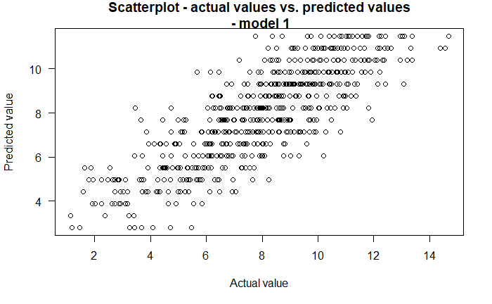

```r
plot(lungCap_mod_rmse_train$LungCap, lungCap_mod_rmse_train$predModel1Train, las=1, main="Scatterplot - actual values vs. predicted values\n - model 1", ylab="Predicted value", xlab="Actual value")
```

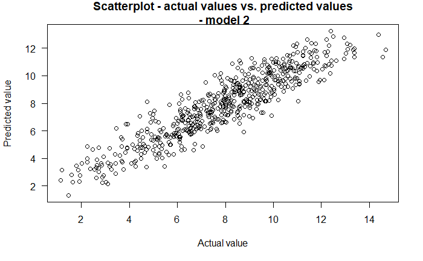

```r
plot(lungCap_mod_rmse_train$LungCap, lungCap_mod_rmse_train$predModel2Train, las=1, main="Scatterplot - actual values vs. predicted values\n - model 2", ylab="Predicted value", xlab="Actual value")
```

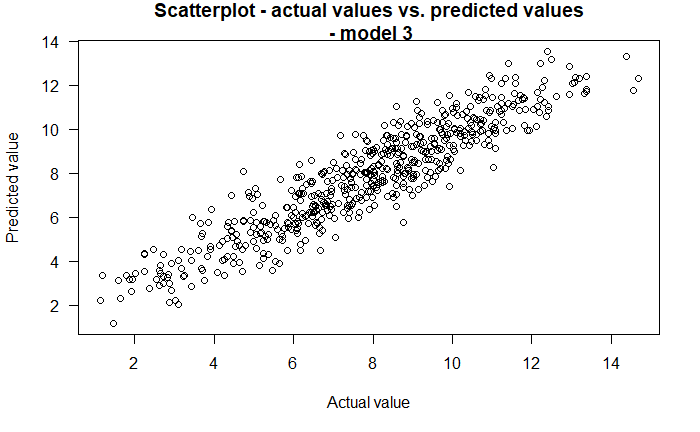

```r
plot(lungCap_mod_rmse_train$LungCap, lungCap_mod_rmse_train$predModel3Train, las=1, main="Scatterplot - actual values vs. predicted values\n - model 3", ylab="Predicted value", xlab="Actual value")
```

```r
#plot(lungCap_mod_rmse_train$LungCap, lungCap_mod_rmse_train$predRegModTrain, las=1, main="Scatterplot - actual values vs. predicted values\n - model 1", ylab="Predicted value", xlab="Actual value")

#plot(lungCap_mod_rmse_train$LungCap, lungCap_mod_rmse_train$predRegModel1Train, las=1, main="Scatterplot - actual values vs. predicted values\n - model 2", ylab="Predicted value", xlab="Actual value")

#plot(lungCap_mod_rmse_train$LungCap, lungCap_mod_rmse_train$predRegModel2Train, las=1, main="Scatterplot - actual values vs. predicted values\n - model 3", ylab="Predicted value", xlab="Actual value")
```

All of the models shows a positive linear relationship between the actual values and predicted values. Some of the data points in model 1 could be outliers, but model 2 and 3 does not seem to have any outliers. The correlation shows that when an actual value increase so does the predicted one. When comparing the three scatterplots it is possible to observe that models with more x-variables is more dense than models with a lesser number of x-variables.

Now I will create the mean squared error for each model.

```r
# model 1
mse_model1 <- lungCap_mod_rmse_train %>% mutate(errorModel1 = predModel1Train - LungCap, sqrErrorModel1 = errorModel1^2) %>% summarise(mse_model1 = mean(sqrErrorModel1))
# model 2
mse_model2 <- lungCap_mod_rmse_train %>% mutate(errorModel2 = predModel2Train - LungCap, sqrErrorModel2 = errorModel2^2) %>% summarise(mse_model2 = mean(sqrErrorModel2))
# model 3
mse_model3 <- lungCap_mod_rmse_train %>% mutate(errorModel3 = predModel3Train - LungCap, sqrErrorModel3 = errorModel3^2) %>% summarise(mse_model3 = mean(sqrErrorModel3))

print(paste0("Mean squared error for model 1: ",mse_model1))
```

```
[1] "Mean squared error for model 1: 2.28795709003217"
```

```r
print(paste0("Mean squared error for model 2: ",mse_model2))
```

```
[1] "Mean squared error for model 2: 1.13669490226121"
```

```r
print(paste0("Mean squared error for model 3: ",mse_model3))
```

```
[1] "Mean squared error for model 3: 1.03749493748472"
```

```r
# model 1
#mse_mod <- lungCap_mod_rmse_train %>% mutate(errorMod = predRegModTrain - LungCap, sqrErrorMod = errorMod^2) %>% summarise(mse_mod = mean(sqrErrorMod))
# model 2
#mse_model1 <- lungCap_mod_rmse_train %>% mutate(errorModel1 = predRegModel1Train - LungCap, sqrErrorModel1 = errorModel1^2) %>% summarise(mse_model1 = mean(sqrErrorModel1))
# model 3
#mse_model2 <- lungCap_mod_rmse_train %>% mutate(errorModel2 = predRegModel2Train - LungCap, sqrErrorModel2 = errorModel2^2) %>% summarise(mse_model2 = mean(sqrErrorModel2))

#print(paste0("Mean squared error for model 1: ",mse_mod))
#print(paste0("Mean squared error for model 2: ",mse_model1))
#print(paste0("Mean squared error for model 3: ",mse_model2))
```

In the above code chunk I first calculate the error which is the predicted value minus the actual value for each model. The sum of the errors for each model sums to zero since some of the values are positive and some of the values are negative and the average mean would be zero. By squaring the errors all the values becomes positive and then I find the average of that. When summarizing I take the mean of the squared error. To get back into my the original scale I need to take the square root of the mean squared error, which I do in the following.

```r
# Model 1
RMSE_model1 <- sqrt(mse_model1)
print(paste0("RMSE for model 1 (training): ", RMSE_model1))
```

```
[1] "RMSE for model 1 (training): 1.51259944798092"
```

```r
# Model 2
RMSE_model2 <- sqrt(mse_model2)
print(paste0("RMSE for model 2 (training): ", RMSE_model2))
```

```
[1] "RMSE for model 2 (training): 1.06615894793469"
```

```r
# Model 3
RMSE_model3 <- sqrt(mse_model3)
print(paste0("RMSE for model 3 (training): ", RMSE_model3))
```

```
[1] "RMSE for model 3 (training): 1.01857495427912"
```

All RMSE values shows a pretty fine average error and they are between 7-11 %. The RMSE values was for the training set, so I will also have to look into the testing set. Remember that the models have not seen the data in the test set and if the model is good I should get a RMSE value for each model that is close to the RMSE value from the training set.

```r
#model 1
pred_reg_test_model1 <- predict(fit_model1, newdata = test)
reg_rmse_test_model1 <- sqrt(mean((pred_reg_test_model1 - test$LungCap)^2))
#model 2
pred_reg_test_model2 <- predict(fit_model2, newdata = test)
reg_rmse_test_model2 <- sqrt(mean((pred_reg_test_model2 - test$LungCap)^2))
#model 1
pred_reg_test_model3 <- predict(fit_model3, newdata = test)
reg_rmse_test_model3 <- sqrt(mean((pred_reg_test_model3 - test$LungCap)^2))

print(paste0("RMSE for model 1 (test): ", reg_rmse_test_model1))
```

```
[1] "RMSE for model 1 (test): 1.56179818624582"
```

```r
print(paste0("RMSE for model 2 (test): ", reg_rmse_test_model2))
```

```
[1] "RMSE for model 2 (test): 0.98786586183215"
```

```r
print(paste0("RMSE for model 3 (test): ", reg_rmse_test_model3))
```

```
[1] "RMSE for model 3 (test): 0.996581262276729"
```

To get the error I took the predicted value and subtracted the actual value. Then I squared the errors to make them positive. Then I took the mean of the squared error and then I took the square root of that. So it is basically the same I did for the training set above.

Now it is time to compare the RMSE value for each model on the test and training set.

```r
diff_model1 <- RMSE_model1 - reg_rmse_test_model1
diff_model2 <- RMSE_model2 - reg_rmse_test_model2
diff_model3 <- RMSE_model3 - reg_rmse_test_model3
print(paste0("The difference between training and test RMSE value on model 1: ",abs(diff_model1)))
```

```
[1] "The difference between training and test RMSE value on model 1: 0.0491987382649006"
```

```r
print(paste0("The difference between training and test RMSE value on model 2: ",abs(diff_model2)))
```

```
[1] "The difference between training and test RMSE value on model 2: 0.0782930861025407"
```

```r
print(paste0("The difference between training and test RMSE value on model 3: ",abs(diff_model3)))
```

```
[1] "The difference between training and test RMSE value on model 3: 0.0219936920023942"
```

When looking at the difference in RMSE value all three models have a very small difference value. That means that the models performs well on both the training and the test set. So the models could be used on other unseen data sets to predict the lung capacity. Model 2 has the largest difference between the RMSE values for test and training set. After that follows model 1. Model 3 has the lowest difference and would therefor be the best model to use on unseen dataset. Model 2 has a larger difference than model 1 which could be explained by an overfitting of the model. However it has to be noted that even model 2 has a very small difference between the training and test set.  
The RMSE value is good if needed to adjust for large, rare errors.

### MAE

In the following I will compute the mean absolute error for all three models, both on the training and the test set. Then I will look at the difference between the MAE value for the training and the test set on each model.

```r
# model 1
mae_train_model1 <- MAE(lungCap_mod_rmse_train$predModel1Train, lungCap_mod_rmse_train$LungCap)
mae_test_model1 <- MAE(pred_reg_test_model1, test$LungCap)
print(paste0("MAE on training set model 1: ",mae_train_model1))
```

```
[1] "MAE on training set model 1: 1.20605040572097"
```

```r
print(paste0("MAE on testing set model 1: ",mae_test_model1))
```

```
[1] "MAE on testing set model 1: 1.26311868593629"
```

```r
print(paste0("The difference between training and test MAE value on model 1: ",abs(mae_train_model1-mae_test_model1)))
```

```
[1] "The difference between training and test MAE value on model 1: 0.0570682802153235"
```

```r
# model 2
mae_train_model2 <- MAE(lungCap_mod_rmse_train$predModel2Train, lungCap_mod_rmse_train$LungCap)
mae_test_model2 <- MAE(pred_reg_test_model2, test$LungCap)
print(paste0("MAE on training set model 2: ",mae_train_model2))
```

```
[1] "MAE on training set model 2: 0.847955848169728"
```

```r
print(paste0("MAE on testing set model 2: ",mae_test_model2))
```

```
[1] "MAE on testing set model 2: 0.797822584768878"
```

```r
print(paste0("The difference between training and test MAE value on model 2: ",abs(mae_train_model2-mae_test_model2)))
```

```
[1] "The difference between training and test MAE value on model 2: 0.0501332634008498"
```

```r
# model 3
mae_train_model3 <- MAE(lungCap_mod_rmse_train$predModel2Train, lungCap_mod_rmse_train$LungCap)
mae_test_model3 <- MAE(pred_reg_test_model3, test$LungCap)
print(paste0("MAE on training set model 3: ",mae_train_model3))
```

```
[1] "MAE on training set model 3: 0.847955848169728"
```

```r
print(paste0("MAE on testing set model 3: ",mae_test_model3))
```

```
[1] "MAE on testing set model 3: 0.821501429212382"
```

```r
print(paste0("The difference between training and test MAE value on model 3: ",abs(mae_train_model3-mae_test_model3)))
```

```
[1] "The difference between training and test MAE value on model 3: 0.0264544189573456"
```

### MAPE

One problem with the MAE is that the relative size of the error is not always obvious. Sometimes it is hard to tell a big error from a small error. To deal with this problem, I can find the mean absolute error in percentage terms. Mean Absolute Percentage Error (MAPE) allows me to compare forecasts of different series in different scales.[^4]  
In the following I will compute the MAPE value for each model. This is done by finding the error by subtracting the predicted value from the actual value. Then I find the absolute value of the error and divide it by the actual value and multiply it with 100. I sum up all the absolute errors in percent and divide them by the number of rows, which will give me the average in percentage.  
I do this for each model on both the training and the testing set.

```r
# model 1 train
actual <- train$LungCap
predicted <- lungCap_mod_rmse_train$predModel1Train
error <- actual - predicted
absolute_error <- abs(error)
absolute_persent_error <- absolute_error / actual * 100
sum_of_column <- sum(absolute_persent_error)
num_of_rows <- 580
mape_model1_train <- sum_of_column/num_of_rows
print(paste0("The MAPE in percentage for model 1 on the training set is: ", mape_model1_train))
```

```
[1] "The MAPE in percentage for model 1 on the training set is: 19.9111053369656"
```

```r
# model 1 test
actual <- test$LungCap
predicted <- pred_reg_test_model1
error <- actual - predicted
absolute_error <- abs(error)
absolute_persent_error <- absolute_error / actual * 100
sum_of_column <- sum(absolute_persent_error)
num_of_rows <- 144
mape_model1_test <- sum_of_column/num_of_rows
print(paste0("The MAPE in percentage for model 1 on the test set is: ", mape_model1_test))
```

```
[1] "The MAPE in percentage for model 1 on the test set is: 21.173937217079"
```

```r
print(paste0("The difference between the MAPE value on test and training set for model 1 is ", abs(mape_model1_train - mape_model1_test)))
```

```
[1] "The difference between the MAPE value on test and training set for model 1 is 1.26283188011337"
```

```r
# model 2 train
actual <- train$LungCap
predicted <- lungCap_mod_rmse_train$predModel2Train
error <- actual - predicted
absolute_error <- abs(error)
absolute_persent_error <- absolute_error / actual * 100
sum_of_column <- sum(absolute_persent_error)
num_of_rows <- 580
mape_model2_train <- sum_of_column/num_of_rows
print(paste0("The MAPE in percentage for model 2 on the training set is: ", mape_model2_train))
```

```
[1] "The MAPE in percentage for model 2 on the training set is: 13.2407647928105"
```

```r
# model 2 test
actual <- test$LungCap
predicted <- pred_reg_test_model2
error <- actual - predicted
absolute_error <- abs(error)
absolute_persent_error <- absolute_error / actual * 100
sum_of_column <- sum(absolute_persent_error)
num_of_rows <- 144
mape_model2_test <- sum_of_column/num_of_rows
print(paste0("The MAPE in percentage for model 2 on the test set is: ", mape_model2_test))
```

```
[1] "The MAPE in percentage for model 2 on the test set is: 12.7824721527121"
```

```r
print(paste0("The difference between the MAPE value on test and training set for model 2 is ", abs(mape_model2_train - mape_model2_test)))
```

```
[1] "The difference between the MAPE value on test and training set for model 2 is 0.458292640098373"
```

```r
# model 3 train
actual <- train$LungCap
predicted <- lungCap_mod_rmse_train$predModel3Train
error <- actual - predicted
absolute_error <- abs(error)
absolute_persent_error <- absolute_error / actual * 100
sum_of_column <- sum(absolute_persent_error)
num_of_rows <- 580
mape_model3_train <- sum_of_column/num_of_rows
print(paste0("The MAPE in percentage for model 3 on the training set is: ", mape_model3_train))
```

```
[1] "The MAPE in percentage for model 3 on the training set is: 12.9889835277503"
```

```r
# model 3 test
actual <- test$LungCap
predicted <- pred_reg_test_model3
error <- actual - predicted
absolute_error <- abs(error)
absolute_persent_error <- absolute_error / actual * 100
sum_of_column <- sum(absolute_persent_error)
num_of_rows <- 144
mape_model3_test <- sum_of_column/num_of_rows
print(paste0("The MAPE in percentage for model 3 on the test set is: ", mape_model3_test))
```

```
[1] "The MAPE in percentage for model 3 on the test set is: 13.0047411543039"
```

```r
print(paste0("The difference between the MAPE value on test and training set for model 3 is ", abs(mape_model3_train - mape_model3_test)))
```

```
[1] "The difference between the MAPE value on test and training set for model 3 is 0.0157576265536257"
```

From the difference in MAPE value on test and training set I can conclude that for all three models the difference is very small. Model 1 had the largest difference with 1.26 %, followed by model 2 with 0.46 % and finally model 3 with the smallest difference between the test and training values with 0.02 %. When all three models have such low difference I can without bigger harm use any of the three models on other unseen data sets.

But just because a model has a small difference between the training and test set does not mean that the model itself is accurate. For this I can look at the MAPE value. Model 1 has a MAPE value on the test set for 21.17 %. Model 2 had 12.78 % and model 3 had 13.00 %. Looking at these values the model 2 would be the preferred model to use to forecast values, since it has the smallest size of error in percentage.  
As a general remark model 2 and model 3 tends to be able to produce the same output on an unseen data set. Both models would be advisable to use, depending on what kind of errors one would like to adjust for. Model 1 seems to perform with a lower accuracy than model 2 and model 3.

# Lottery - Stage 4

## Viking Lotto

I have chosen one of the Danish lottery systems, known as “Viking Lotto”, which can be found here: https://danskespil.dk/vikinglotto/vindertal

The lottery ticket has a game board with 36 elements which are the numbers from 1-36. The player should choose 7 numbers on the game board - this is known as a row.

Once a week the lottery numbers are drawn. There is drawn 7 winning numbers and 2 additional numbers.  
The criteria for a success is:  
- 6 winning numbers plus 1 of the additional numbers.  
- 6 winning numbers.  
- 5 winning numbers plus 1 of the additional numbers.  
- 5 winning numbers.  
- 4 winning numbers plus 1 of the additional numbers.  
- 4 winning numbers.  
- 3 winning numbers.

In the lottery the sequence of the 7 winning numbers is selected among the first 36 positive integers and the sequence of the winning numbers is not relevant. To calculate the possible sequences of winning numbers I use the formula:  
(n,k) = n(n-1)…(n-k+1) / k(k-1)…1  
The same formula can be written with factorials:  
n! / (k!*(n-k)!), when k <= n, and which is zero when k>n.

```r
kombin <- function(n,k)
{
  factorial(n) / (factorial(k)*factorial(n-k))
}
```

The number of possible rows is (36,7) = 8347680.

```r
kombin(36,7)
```

[output not shown]

I will start out with the simplest of the cases where I only focus on the winning numbers.  
Let x denote the number of correct winning numbers.  
The number of rows with x number of correct winning numbers is (7,x)(29,7-x), which is the number of ways the correct x numbers can be among the correct 7 winning numbers multiplied with the number of ways the remaining 7-x numbers in the row can be selected from the 29 numbers which are not the correct winning numbers.  
P(x) = ((7,x)(29,7-x)) / (36,7)  
**x = 6**

```r
(kombin(7,6)*kombin(29,7-6)) / kombin(36,7)
```

[output not shown]

**x = 5**

```r
(kombin(7,5)*kombin(29,7-5)) / kombin(36,7)
```

[output not shown]

**x = 4**

```r
(kombin(7,4)*kombin(29,7-4)) / kombin(36,7)
```

[output not shown]

**x = 3**

```r
(kombin(7,3)*kombin(29,7-3)) / kombin(36,7)
```

```
[1] 0.09958276
```

The above results only focus on the cases where the winning numbers are drawn and not the additional numbers. The additional numbers is two numbers. Let y denote the number of correct additional numbers. I can either have 0, 1 or 2 correct additional numbers.  
I will use the following formula:  
P(x correct winning numbers and y correct additional numbers) = ( (7,x)* (2,y)* (27,7-(x+y)) ) / (36,7)

First I’ll find the number of combinations for x to be among the correct 7 winning numbers, they are multiplied with the number of combinations for y to be among the correct 2 additional numbers, multiplied with the number of ways where the remaining 7-(x and y) numbers of the row is selected among the 27 numbers which is not correct.

If I have **6 winning numbers and 1 additional number** the formula looks like this:  
P(6,1) = ( (7,6)* (2,1)* (27,7-(6+1)) ) / (36,7)

```r
(kombin(7,6)*kombin(2,1)*kombin(27,7-(6+1))) / kombin(36,7)
```

```
[1] 1.677113e-06
```

**5 winning numbers and 1 additional number**

```r
(kombin(7,5)*kombin(2,1)*kombin(27,7-(5+1))) / kombin(36,7)
```

```
[1] 0.0001358461
```

**4 winning numbers and 1 additional number**

```r
(kombin(7,4)*kombin(2,1)*kombin(27,7-(4+1))) / kombin(36,7)
```

```
[1] 0.002943333
```

It would make sense that the lower the probability the higher the price. The order of the price is related to the number of correct winning numbers and additional numbers: 6 winning numbers + 1 additional number > 6 winning numbers > 5 winning numbers + 1 additional number > 5 winning numbers > 4 winning numbers + 1 additional number > 4 winning numbers > 3 winning numbers.  
Let’s compare the probability the highest price should have the lowest probability

```r
"(kombin(7,6)*kombin(2,1)*kombin(27,7-(6+1))) / kombin(36,7)"<"(kombin(7,6)*kombin(29,7-6)) / kombin(36,7)<(kombin(7,5)*kombin(2,1)*kombin(27,7-(5+1))) / kombin(36,7)<(kombin(7,5)*kombin(29,7-5)) / kombin(36,7)<(kombin(7,4)*kombin(2,1)*kombin(27,7-(4+1))) / kombin(36,7)<(kombin(7,4)*kombin(29,7-4)) / kombin(36,7)<(kombin(7,3)*kombin(29,7-3)) / kombin(36,7)"
```

```
[1] TRUE
```

```r
(kombin(7,6)*kombin(2,1)*kombin(27,7-(6+1))) / kombin(36,7)
```

```
[1] 1.677113e-06
```

```r
(kombin(7,6)*kombin(29,7-6)) / kombin(36,7)
```

```
[1] 2.431813e-05
```

```r
(kombin(7,5)*kombin(2,1)*kombin(27,7-(5+1))) / kombin(36,7)
```

```
[1] 0.0001358461
```

```r
(kombin(7,5)*kombin(29,7-5)) / kombin(36,7)
```

```
[1] 0.001021362
```

```r
(kombin(7,4)*kombin(2,1)*kombin(27,7-(4+1))) / kombin(36,7)
```

```
[1] 0.002943333
```

```r
(kombin(7,4)*kombin(29,7-4)) / kombin(36,7)
```

```
[1] 0.01532042
```

```r
(kombin(7,3)*kombin(29,7-3)) / kombin(36,7)
```

```
[1] 0.09958276
```

I have both evaluated that the highest price is associated with the lowest probability and when the probability increases the price is decreasing. It can be observed that there is a lower probability of getting x number of winning numbers and the additional numbers, than just the winning numbers. This makes quite good sense the probability of the correct additional numbers is multiplied in the equation. If we look at the result numbers we have to remember that it is a value between 0-1, where 0 indicates no probability of the outcome (it is impossible) and 1 indicates it will happen for sure. There is a very small chance to win in the lottery, even just to have 3 correct winning numbers.

[^1]: From https://www.ncbi.nlm.nih.gov/books/NBK541029/, seen 17/12-20.
[^2]: From https://www.r-bloggers.com/2020/01/how-to-remove-outliers-in-r/, seen 23/12-20.
[^3]: From https://canworksmart.com/using-mean-absolute-error-forecast-accuracy/, seen 22/12-20.
[^4]: From https://canworksmart.com/using-mean-absolute-error-forecast-accuracy/, seen 22/12-20.